# Introduction

```r
library(RMASCA)
```

# Introduction to RM-ASCA+

## Creating a dummy data set

Let us start out by creating some dummy data for us to work with. In this example we have 600 participants measured four different times. The participants belonged to three different groups – for example control group, chocolate diet and salad diet – and we measured ten variables each time.

```r
nPart <- 600
nGroups <- c("Controls", "Chocolate", "Salad")
nTime <- c(1, 2, 3, 4)
variables <- c("BMI", "Glucose", "VLDL", "LDL", "HDL", "ferritin", "CRP", "Happiness", "Anger", "Age")
```

The `RMASCA()` function expects a data frame in long format that contains at least one column for time (called `time`), one for group (called `group`) and one for variables (called `variable`).

```r
df <- data.frame(
  partid = c(1:nPart),
  group = nGroups[sample(c(1:length(unique(nGroups))), nPart, replace = TRUE)]
)
df$time <- nTime[1]
df_temp_temp <- df
for(i in nTime[2:length(nTime)]){
  df_temp <- df_temp_temp
  df_temp$time <- i
  df <- rbind(df, df_temp)
}
for(i in 1:length(variables)){
  df[,3+i] <- rnorm(nrow(df), mean = 10, sd = 3)
}
colnames(df) <- c("partid", "group", "time", variables)
```

Random data aren’t very interesting, so let us add some trends.

- Control group: These are boring and serve as reference
- Chocolate group: Let us imagine they responded something like
  - Increasing BMI and glucose
  - Initially decreased anger and increased happiness, but only at time 2 and 3 (before the stomach begins to hurt…)
- Salad group: Let us imagine they responded something like
  - Decreasing BMI and glucose
  - Initially increased anger and decreased happiness, but only at time 2 and 3 before they get used to it and start to enjoy their new life

The age and HDL, however, increases for all groups, and the other variables are unaffected and vary at random.

```r
df$Anger[df$group == "Chocolate" & df$time == 2] <- df$Anger[df$group == "Chocolate" & df$time == 1]/2
df$Anger[df$group == "Chocolate" & df$time == 3] <- df$Anger[df$group == "Chocolate" & df$time == 1]/1.5
df$Happiness[df$group == "Chocolate" & df$time == 2] <- df$Happiness[df$group == "Chocolate" & df$time == 1]*2
df$Happiness[df$group == "Chocolate" & df$time == 3] <- df$Happiness[df$group == "Chocolate" & df$time == 1]*1.5
df$BMI[df$group == "Chocolate"] <- df$BMI[df$group == "Chocolate"]*df$time[df$group == "Chocolate"]
df$Glucose[df$group == "Chocolate"] <- df$Glucose[df$group == "Chocolate"]*df$time[df$group == "Chocolate"]

df$Anger[df$group == "Salad" & df$time == 2] <- df$Anger[df$group == "Salad" & df$time == 1]*2
df$Anger[df$group == "Salad" & df$time == 3] <- df$Anger[df$group == "Salad" & df$time == 1]*1.5
df$Happiness[df$group == "Salad" & df$time == 2] <- df$Happiness[df$group == "Salad" & df$time == 1]/2
df$Happiness[df$group == "Salad" & df$time == 3] <- df$Happiness[df$group == "Salad" & df$time == 1]/1.5
df$BMI[df$group == "Salad"] <- df$BMI[df$group == "Salad"]/df$time[df$group == "Salad"]
df$Glucose[df$group == "Salad"] <- df$Glucose[df$group == "Salad"]/df$time[df$group == "Salad"]

df$Age <- df$Age*df$time
df$HDL <- df$HDL*df$time
```

```r
df$group <- factor(df$group)
df$group <- relevel(df$group, ref = "Controls")
df <- reshape2::melt(df, id.vars = c("partid", "group", "time"))
for(i in unique(df$variables)){
  for(j in unique(df$partid)){
    df$value[df$variables == i & df$partid == j] <- df$value[df$variables == i & df$partid == j] + sample(0:5,1)
  }
}
```

Let us see how it looks

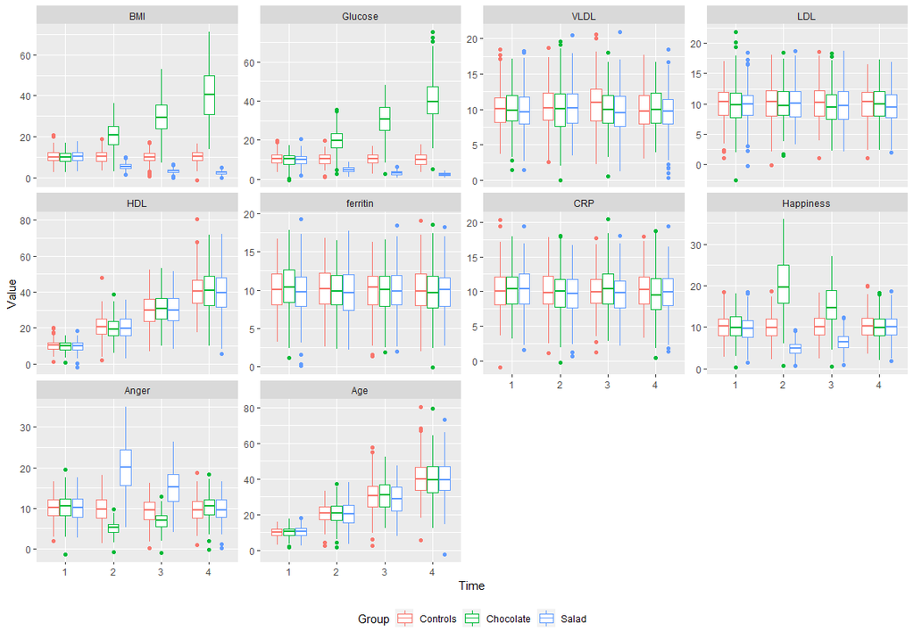

```r
ggplot2::ggplot(data = df,
                ggplot2::aes(x = factor(time), y = value, color = group)) +
  ggplot2::geom_boxplot() +
  ggplot2::facet_wrap(~variable, scales = "free_y") +
  ggplot2::theme(legend.position = "bottom") +
  ggplot2::labs(x = "Time", y = "Value", color = "Group")
```

And we can have a look at some random participants to see typical trajectories

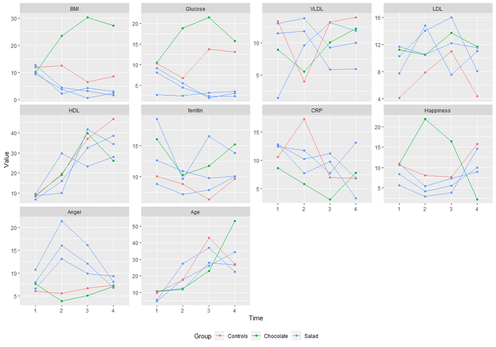

```r
ggplot2::ggplot(data = subset(df, partid %in% sample(unique(partid), 5)),
     ggplot2::aes(x = factor(time), y = value, group = partid, color = group)) +
     ggplot2::geom_point() + ggplot2::geom_line() +
     ggplot2::facet_wrap(~variable, scales = "free_y") +
     ggplot2::theme(legend.position = "bottom") +
     ggplot2::labs(x = "Time", y = "Value", color = "Group")
```

## Using RM-ASCA+

Now that we have a data set, let us try the `RMASCA()` function! First we need to decide what kind of model we want. For simplicity, let us start with a very simple model with terms for time, group and interaction.

```r
model.formula <- value ~ time*group + (1|partid)
res.simple <- RMASCA(df = df, formula = model.formula)
```

```
#> Scaling data...
#> Calculating LMM coefficients...
#> -  BMI
#> boundary (singular) fit: see ?isSingular
#> -  Glucose
#> boundary (singular) fit: see ?isSingular
#> -  VLDL
#> boundary (singular) fit: see ?isSingular
#> -  LDL
#> boundary (singular) fit: see ?isSingular
#> -  HDL
#> boundary (singular) fit: see ?isSingular
#> -  ferritin
#> -  CRP
#> -  Happiness
#> -  Anger
#> -  Age
#> boundary (singular) fit: see ?isSingular
#> Finished calculating LMM coefficients!
#> Calculating effect matrix (may take some time...)
#> Finished calculating effect matrix!
```

To visualize the result, simply use `plot(res.simple)`;

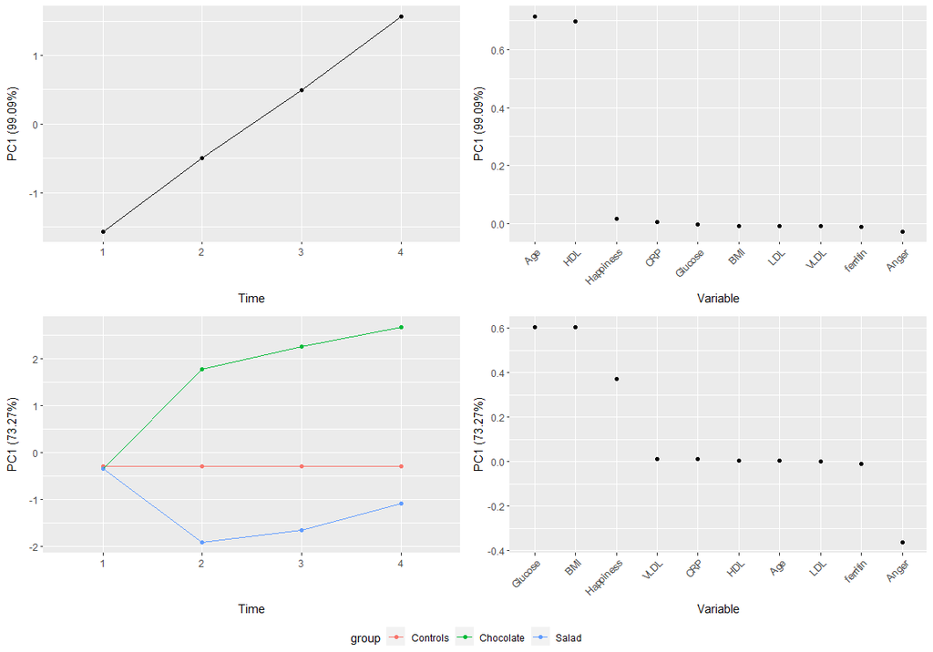

```r
plot(res.simple)
```

Let us interpret the figure from top left:

- Top left: The control group has some variable – one or more – that increases steadily
- Top right: The variables that increase are age and HDL
- Bottom left: Relative to the control group, the chocolate group increases in some variable and the salad group decreases
- Bottom right: The variables that increase for the chocolate group (and decreases for the salad group) are mainly BMI and glucose

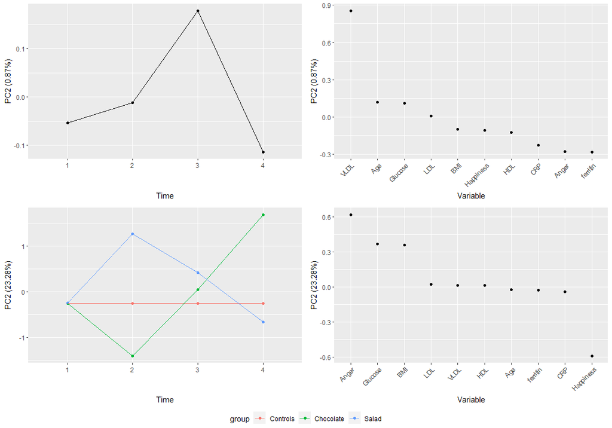

```r
plot(res.simple, component = "PC2")
```

#### Scree plots

So, how many components do we need? With PCA, the first component is always the one explaining most variance. We can look at how much the various components explain,

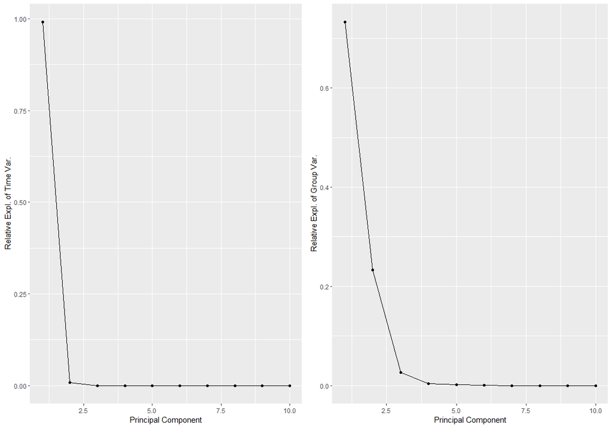

```r
screeplot(res.simple)
```

And it seems that we should use PC1 for the time effect, but probably both PC1 and PC2 for the group effect. Which makes sense, since we added several distinct group trends to our data that needs different trajectories to be explained.

### Customized plots

Often, we want some more control over the plots. Luckily, we can easily get the necessary data using `getLoadings()` and `getScores()`. For example

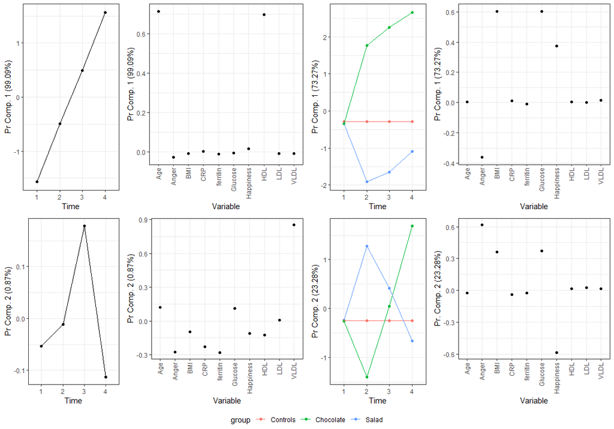

```r
scores <- getScores(res.simple)
loadings <- getLoadings(res.simple)

gst_1 <- ggplot2::ggplot(scores$time, ggplot2::aes(x = time, y = PC1, group = NA)) +
  ggplot2::geom_point() +
  ggplot2::geom_line() +
  ggplot2::theme_bw() +
  ggplot2::labs(x = "Time", y = paste0("Pr Comp. 1 (",round(100*scores$explained$time[1], 2),"%)"))

gst_2 <- ggplot2::ggplot(scores$time, ggplot2::aes(x = time, y = PC2, group = NA)) +
  ggplot2::geom_point() +
  ggplot2::geom_line() +
  ggplot2::theme_bw() +
  ggplot2::labs(x = "Time", y = paste0("Pr Comp. 2 (",round(100*scores$explained$time[2], 2),"%)"))

gsg_1 <- ggplot2::ggplot(scores$group, ggplot2::aes(x = time, y = PC1, group = group, color = group)) +
  ggplot2::geom_point() +
  ggplot2::geom_line() +
  ggplot2::theme_bw() +
  ggplot2::labs(x = "Time", y = paste0("Pr Comp. 1 (",round(100*scores$explained$group[1], 2),"%)"))

gsg_2 <- ggplot2::ggplot(scores$group, ggplot2::aes(x = time, y = PC2, group = group, color = group)) +
  ggplot2::geom_point() +
  ggplot2::geom_line() +
  ggplot2::theme_bw() +
  ggplot2::labs(x = "Time", y = paste0("Pr Comp. 2 (",round(100*scores$explained$group[2], 2),"%)"))

glt_1 <- ggplot2::ggplot(loadings$time, ggplot2::aes(x = covars, y = PC1)) +
  ggplot2::geom_point() +
  ggplot2::labs(x = "Variable", y = paste0("Pr Comp. 1 (",round(100*loadings$explained$time[1], 2),"%)")) +
  ggplot2::theme_bw() +
  ggplot2::theme(axis.text.x = ggplot2::element_text(angle = 90, vjust = 0.4, hjust=1))

glt_2 <- ggplot2::ggplot(loadings$time, ggplot2::aes(x = covars, y = PC2)) +
  ggplot2::geom_point() +
  ggplot2::labs(x = "Variable", y = paste0("Pr Comp. 2 (",round(100*loadings$explained$time[2], 2),"%)")) +
  ggplot2::theme_bw() +
  ggplot2::theme(axis.text.x = ggplot2::element_text(angle = 90, vjust = 0.4, hjust=1))

glg_1 <- ggplot2::ggplot(loadings$group, ggplot2::aes(x = covars, y = PC1)) +
  ggplot2::geom_point() +
  ggplot2::labs(x = "Variable", y = paste0("Pr Comp. 1 (",round(100*loadings$explained$group[1], 2),"%)")) +
  ggplot2::theme_bw() +
  ggplot2::theme(axis.text.x = ggplot2::element_text(angle = 90, vjust = 0.4, hjust=1))

glg_2 <- ggplot2::ggplot(loadings$group, ggplot2::aes(x = covars, y = PC2)) +
  ggplot2::geom_point() +
  ggplot2::labs(x = "Variable", y = paste0("Pr. Comp. 2 (",round(100*loadings$explained$group[2], 2),"%)")) +
  ggplot2::theme_bw() +
  ggplot2::theme(axis.text.x = ggplot2::element_text(angle = 90, vjust = 0.4, hjust=1))

ggpubr::ggarrange(
  ggpubr::ggarrange(gst_1, glt_1, gsg_1, glg_1, nrow = 1, widths = c(2,3,2,3), common.legend = TRUE, legend = "none"),
  ggpubr::ggarrange(gst_2, glt_2, gsg_2, glg_2, nrow = 1, widths = c(2,3,2,3), common.legend = TRUE, legend = "bottom"),
  nrow = 2
)
```

### Robustness testing

```r
res.simple$nValRuns <- 50 # the more, the better

res.simple <- validate(res.simple, participantColumn = "partid")
```

[output not shown]

[output cut: 232 more lines]

[output not shown]

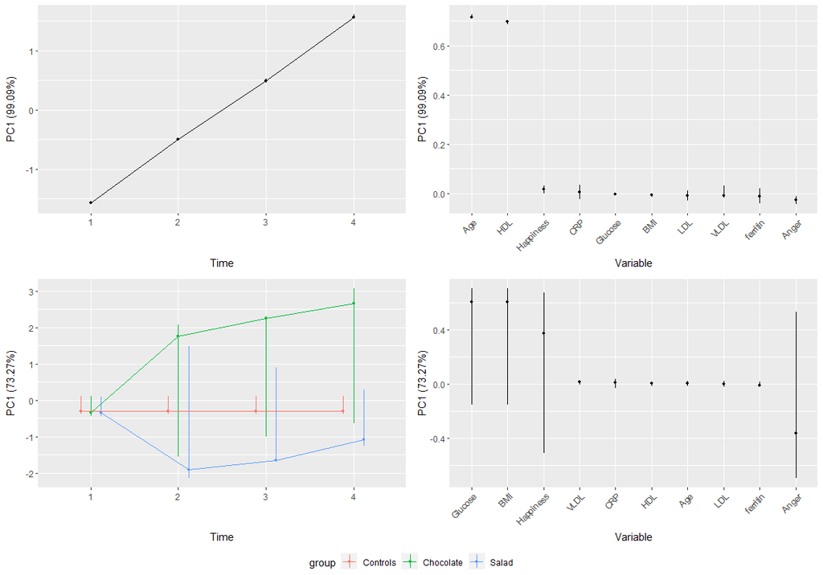

```r
plot(res.simple)
```

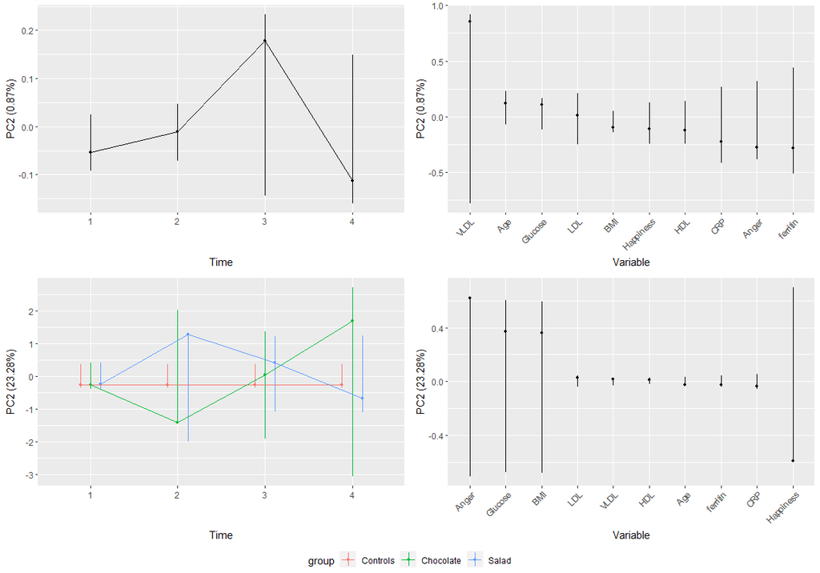

```r
plot(res.simple, component = "PC2")
```

### Alternative models

#### Interaction only

If our experiment was an intervention, then we can assume that the groups were equal at baseline (time 1). Then we can skip the main group effect and only use time and interaction, like this:

```r
model.formula <- value ~ time + time:group + (1|partid)
res.mod2 <- RMASCA(df = df, formula = model.formula)
```

```
#> Scaling data...
#> Calculating LMM coefficients...
#> -  BMI
#> boundary (singular) fit: see ?isSingular
#> -  Glucose
#> boundary (singular) fit: see ?isSingular
#> -  VLDL
#> boundary (singular) fit: see ?isSingular
#> -  LDL
#> boundary (singular) fit: see ?isSingular
#> -  HDL
#> boundary (singular) fit: see ?isSingular
#> -  ferritin
#> -  CRP
#> -  Happiness
#> -  Anger
#> -  Age
#> boundary (singular) fit: see ?isSingular
#> Finished calculating LMM coefficients!
#> Calculating effect matrix (may take some time...)
#> Finished calculating effect matrix!
```

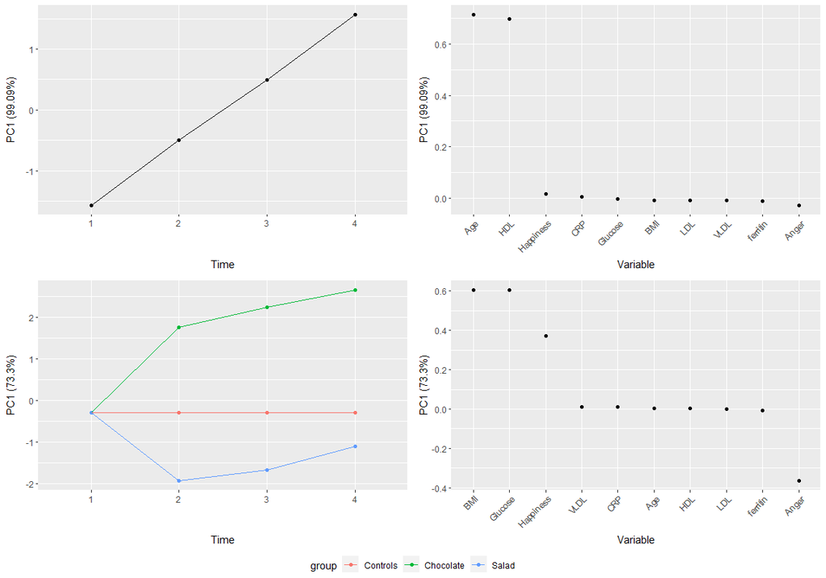

```r
plot(res.mod2)
```

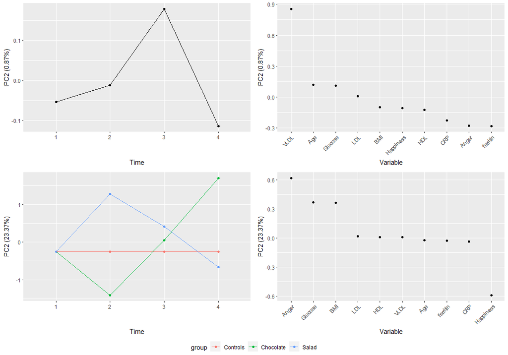

```r
plot(res.mod2, component = "PC2")
```

As you can see, it is quite similar to the previous model, but all the groups have the same value for time 1.

#### Interaction only with combined time and group effect

Sometimes it doesn’t make sense to use a reference group – for example if we didn’t have any controls and the first group had a salt-free diet. We can then use a single PCA instead of separating time and group effects:

```r
model.formula <- value ~ time + time:group + (1|partid)
res.mod3 <- RMASCA(df = df, formula = model.formula, separateTimeAndGroup = FALSE)
```

```
#> Scaling data...
#> Calculating LMM coefficients...
#> -  BMI
#> boundary (singular) fit: see ?isSingular
#> -  Glucose
#> boundary (singular) fit: see ?isSingular
#> -  VLDL
#> boundary (singular) fit: see ?isSingular
#> -  LDL
#> boundary (singular) fit: see ?isSingular
#> -  HDL
#> boundary (singular) fit: see ?isSingular
#> -  ferritin
#> -  CRP
#> -  Happiness
#> -  Anger
#> -  Age
#> boundary (singular) fit: see ?isSingular
#> Finished calculating LMM coefficients!
#> Calculating effect matrix (may take some time...)
#> Finished calculating effect matrix!
```

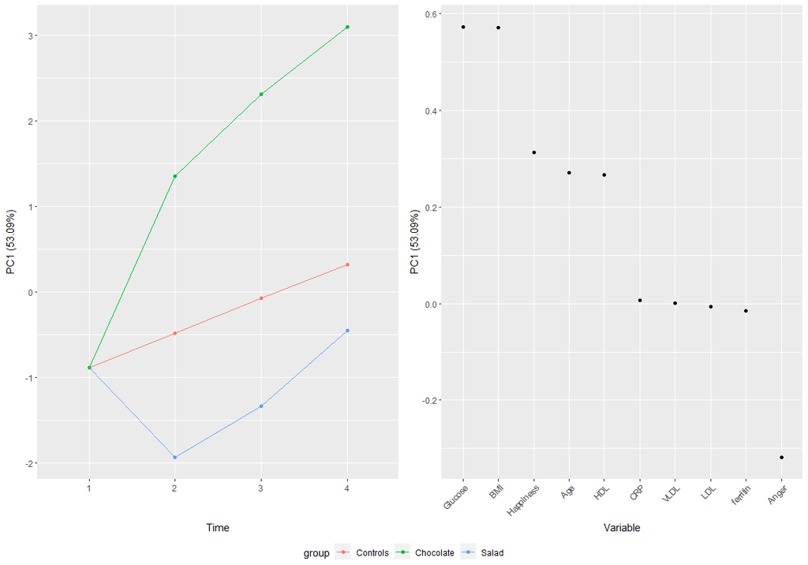

```r
plot(res.mod3)
```

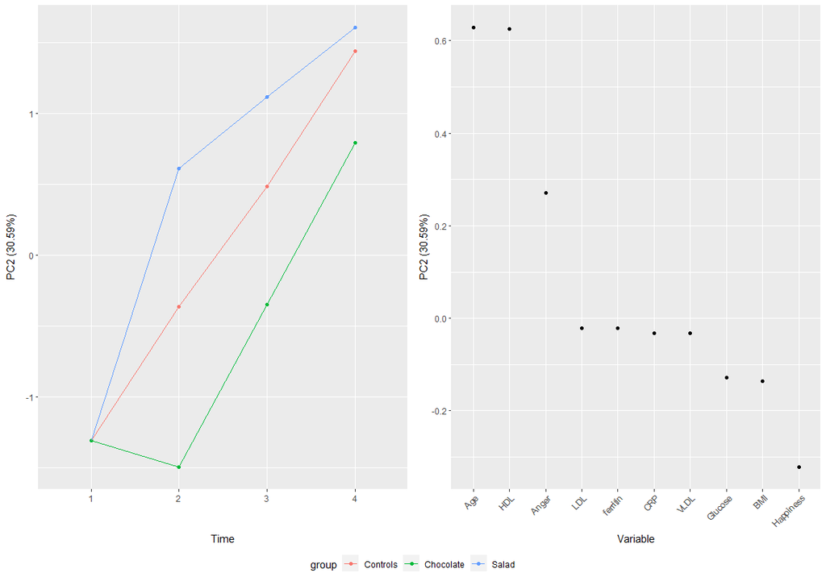

```r
plot(res.mod3, component = "PC2")
```

#### Covariates

This time we want to adjust for age and not include it in the ASCA itself;

```r
age <- subset(df, variable == "Age")$value
df <- subset(df, variable != "Age")
df$age <- age
model.formula <- value ~ time + time:group + age + (1|partid)
res.mod4 <- RMASCA(df = df, formula = model.formula)
```

```
#> Scaling data...
#> Calculating LMM coefficients...
#> -  BMI
#> boundary (singular) fit: see ?isSingular
#> -  Glucose
#> boundary (singular) fit: see ?isSingular
#> -  VLDL
#> boundary (singular) fit: see ?isSingular
#> -  LDL
#> boundary (singular) fit: see ?isSingular
#> -  HDL
#> boundary (singular) fit: see ?isSingular
#> -  ferritin
#> -  CRP
#> -  Happiness
#> -  Anger
#> Finished calculating LMM coefficients!
#> Calculating effect matrix (may take some time...)
#> Finished calculating effect matrix!
```

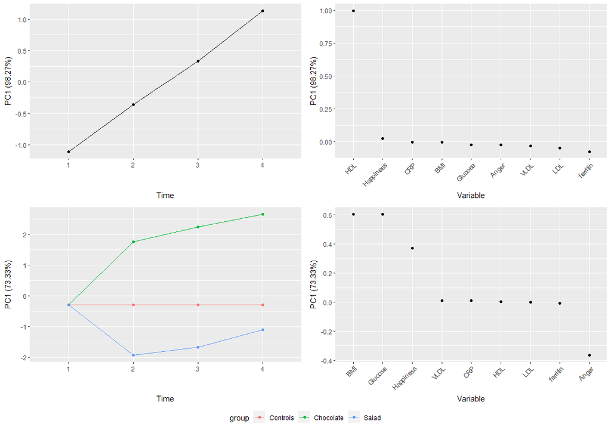

```r
plot(res.mod4)
```

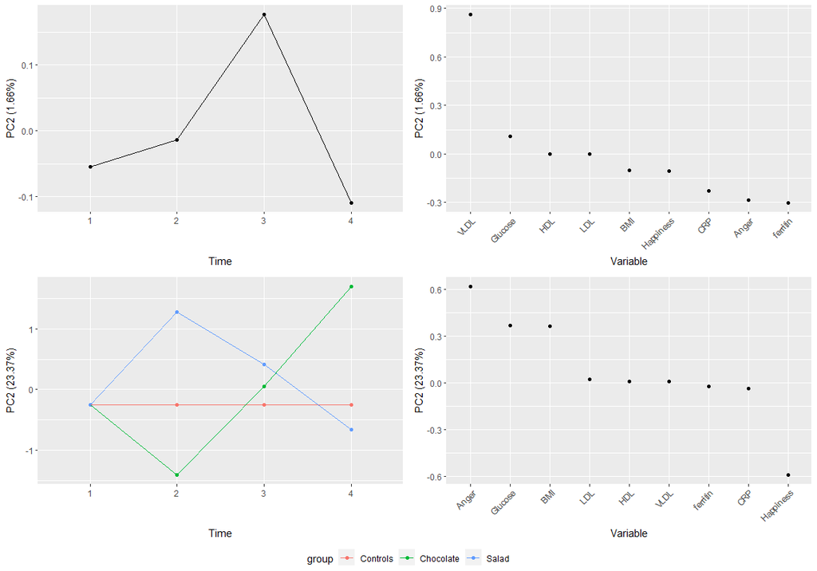

```r
plot(res.mod4, component = "PC2")
```

We can see that the linear increase in age is no longer part of the output.

## Diagnostics

### Normal distribution of residuals

RM-ASCA+ is built on Linear Mixed Models, and one should check that the residuals approach normal distribution. With `RMASCA`, the LMM objects can be found as

```r
summary(res.simple$lmer.models[[1]])
```

```
#> Linear mixed model fit by REML. t-tests use Satterthwaite's method [
#> lmerModLmerTest]
#> Formula: object$formula
#>    Data: subset(object$df, variable == i)
#>
#> REML criterion at convergence: 2781.2
#>
#> Scaled residuals:
#>     Min      1Q  Median      3Q     Max
#> -5.1345 -0.3440 -0.0056  0.3625  6.0103
#>
#> Random effects:
#>  Groups   Name        Variance Std.Dev.
#>  partid   (Intercept) 0.0000   0.0000
#>  Residual             0.1827   0.4274
#> Number of obs: 2400, groups:  partid, 600
#>
#> Fixed effects:
#>                        Estimate Std. Error         df t value Pr(>|t|)
#> (Intercept)          -2.596e-01  3.168e-02  2.388e+03  -8.193 4.11e-16 ***
#> time2                -3.157e-03  4.481e-02  2.388e+03  -0.070    0.944
#> time3                -3.683e-02  4.481e-02  2.388e+03  -0.822    0.411
#> time4                -1.652e-02  4.481e-02  2.388e+03  -0.369    0.712
#> groupChocolate       -3.063e-02  4.364e-02  2.388e+03  -0.702    0.483
#> groupSalad           -1.143e-02  4.306e-02  2.388e+03  -0.265    0.791
#> time2:groupChocolate  8.774e-01  6.171e-02  2.388e+03  14.219  < 2e-16 ***
#> time3:groupChocolate  1.677e+00  6.171e-02  2.388e+03  27.170  < 2e-16 ***
#> time4:groupChocolate  2.526e+00  6.171e-02  2.388e+03  40.934  < 2e-16 ***
#> time2:groupSalad     -4.069e-01  6.089e-02  2.388e+03  -6.683 2.90e-11 ***
#> time3:groupSalad     -5.425e-01  6.089e-02  2.388e+03  -8.910  < 2e-16 ***
#> time4:groupSalad     -6.302e-01  6.089e-02  2.388e+03 -10.351  < 2e-16 ***
#> ---
#> Signif. codes:  0 '***' 0.001 '**' 0.01 '*' 0.05 '.' 0.1 ' ' 1
#>
#> Correlation of Fixed Effects:
#>             (Intr) time2  time3  time4  grpChc grpSld tm2:gC tm3:gC tm4:gC
#> time2       -0.707
#> time3       -0.707  0.500
#> time4       -0.707  0.500  0.500
#> groupChoclt -0.726  0.513  0.513  0.513
#> groupSalad  -0.736  0.520  0.520  0.520  0.534
#> tm2:grpChcl  0.513 -0.726 -0.363 -0.363 -0.707 -0.378
#> tm3:grpChcl  0.513 -0.363 -0.726 -0.363 -0.707 -0.378  0.500
#> tm4:grpChcl  0.513 -0.363 -0.363 -0.726 -0.707 -0.378  0.500  0.500
#> tim2:grpSld  0.520 -0.736 -0.368 -0.368 -0.378 -0.707  0.534  0.267  0.267
#> tim3:grpSld  0.520 -0.368 -0.736 -0.368 -0.378 -0.707  0.267  0.534  0.267
#> tim4:grpSld  0.520 -0.368 -0.368 -0.736 -0.378 -0.707  0.267  0.267  0.534
#>             tm2:gS tm3:gS
#> time2
#> time3
#> time4
#> groupChoclt
#> groupSalad
#> tm2:grpChcl
#> tm3:grpChcl
#> tm4:grpChcl
#> tim2:grpSld
#> tim3:grpSld  0.500
#> tim4:grpSld  0.500  0.500
#> convergence code: 0
#> boundary (singular) fit: see ?isSingular
```

We can also assess the residuals,

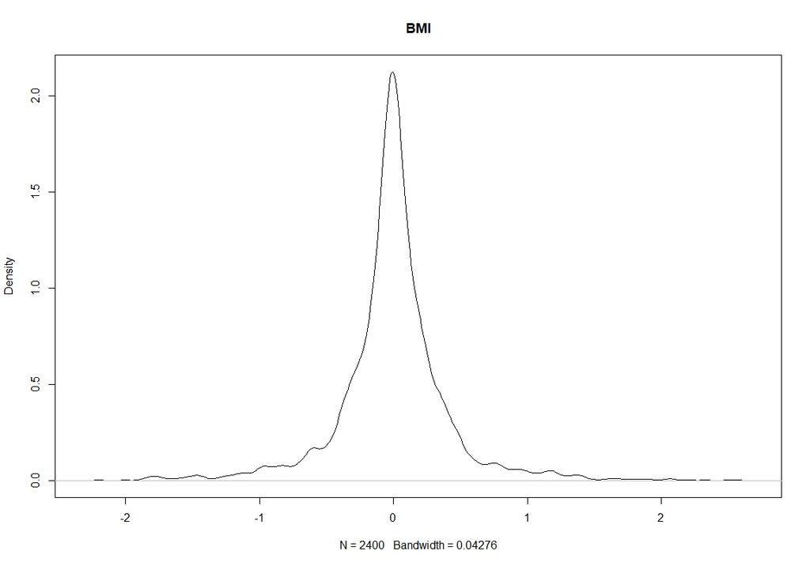

```r
plot(density(residuals(res.simple$lmer.models[[1]])), main = unique(df$variable)[1])
```

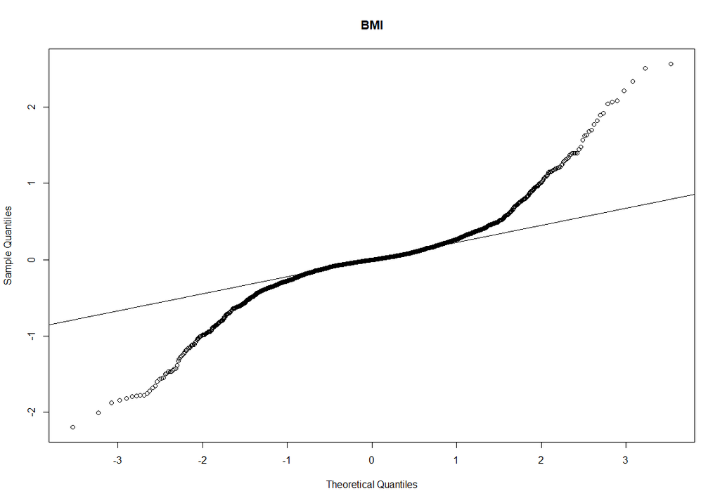

```r
qqnorm(residuals(res.simple$lmer.models[[1]]), main = unique(df$variable)[1])
qqline(residuals(res.simple$lmer.models[[1]]))
```

### P values

As you saw above, we can use the `summary` function to view the p values from your LMMs, but a shortcut is

```r
head(res.simple$LMM.coefficient)
```

```
#>   covar     estimate       pvalue       variable  comp
#> 1   BMI -0.259588848 4.108501e-16    (Intercept)  TIME
#> 2   BMI -0.003156514 9.438462e-01          time2  TIME
#> 3   BMI -0.036833619 4.111501e-01          time3  TIME
#> 4   BMI -0.016519816 7.124044e-01          time4  TIME
#> 5   BMI -0.030633620 4.827178e-01 groupChocolate GROUP
#> 6   BMI -0.011425683 7.907450e-01     groupSalad GROUP
```